# Machine-Learning-vol.13-クラスタリング

## 13.1 クラスタリングの主な活用例

クラスタリングとは､**似ているサンプル同士をグループ（クラスタ）にまとめる教師なし学習の手法**です｡正解ラベルが用意されていないため､**分けられたクラスタには意味付けがされていません**｡そのため､**意味付けは分析者が結果を見て主観的に行う必要があります**｡サンプルをいくつかの組に分けるという点で分類問題とも似ていますが､両者はこの点で異なります｡また､分析者の主観が入るため**客観性には乏しく**､**データの構造にアタリをつけるために利用されることが多い手法**でもあります｡

[figure not shown]

**クラスタリング**の**｢似ているものどうしをグループにまとめる｣****という機能は非常に応用範囲が広く､ビジネスや学術研究で広く利用されています**｡以下には､**私たちに身近なビジネス寄りの例**を挙げました｡

[figure not shown]

#### 1. 顧客のセグメンテーション

ビジネスの現場では､**アンケート**などを利用して**顧客を性別･年齢･職業･世帯人数･嗜好などから細分化する**ことがあります｡たとえば､**｢新商品の車を､高級志向で家族連れが多い層に対して作ろう｣**などの取り決めをします｡これは**セグメンテーション分析**と呼ばれ､**新規事業のターゲットを明確に定義したいとき**などに重宝されます｡

#### 2. 商品のレコメンデーション

**顧客の購買履歴**をもとに､**商品の類似性を分析して､顧客が好みそうな商品を推薦する**こともできます｡**ECサイト**によくある､**｢これを買った人は､こんな商品も買っています｣**という機能がそれにあたります｡**顧客の購買を促すため**に利用されます｡

#### 3. ニュース記事のトピック分類

**ニュース記事含まれている単語**から､**そのニュースのトピックを予測する**と言った場合も**クラスタリング**は役に立ちます｡たとえば､**とあるニュースのトピックが｢政治｣なのか､｢スポーツ｣なのか､｢グルメ｣なのか**を分けると言った感じです｡これによって､**記事の自動タグ付け**が行えます｡

## 13.2 クラスタリングの4つの焦点

さて､**クラスタリングの実用例**について話をしてきましたが､ここからは**アルゴリズムの扱い方**についての話をしていきます｡**クラスタリングを利用するために､どのようなことを考えていけばいいのでしょうか**？一般的に､**クラスタリングのアルゴリズムにおいて**焦点**となる**のは以下の**4点**です｡**これらをどう決めるかで､分析の内容や結果が大きく変わります**｡**クラスタリング**を行おうと思ったときには､**初めにチェックしましょう**｡

### 1. 何を分けるのか？

まずは､**クラスタリングの対象を明確にする**ところから始まります｡具体的には､**顧客などのサンプル**を分けるのか､あるいは**推薦する商品のような変数**を分けるのかに二分されます｡ちなみに､**今回はirisのサンプルを対象にクラスタリングを行います**｡

[figure not shown]

### 2. 階層型か？非階層型か？

次に､**クラスタリングの形式**を選択します｡クラスタリングの形式は大きく2種類あり､**単純に対象のグループ分けを行う非階層型のクラスタリング**と､**類似の段階別にグループ分けを行う階層型のクラスタリング**です｡**階層型**のクラスタリングは図のような**木構造**を作るので､**決定木**による分類が思い出されます｡両者の違いは､やはり**利用するデータが教師ありデータなのか､教師なしデータなのか**です｡**今回の内容では､非階層型のクラスタリングのみを扱います**｡

[figure not shown]

### 3. 類似度を何で定義するか？

次に重要なのが､**グループ分けの基準**になる**類似度の定義**です｡**類似性とは性質の近さであり､近さとは特徴空間における距離のことです**｡そこで､**特徴空間内でどのように距離を測るか**を決めます｡直交座標系で使う**ユークリッド距離**､特徴量の相関を考慮した**マハラノビス距離**､ベクトルの向きで類似性を評価する**コサイン距離**などがあり､これを使い分けていきます｡ また､**今回はユークリッド距離だけを利用します**｡

[figure not shown]

### 4. どのアルゴリズムを使うか？

**クラスタリング**と一口に言っても､**そのアルゴリズムはいくつかあります**｡**アルゴリズムごとに特性があるので､目的やデータの状態によって使い分けが必要です**｡今回は､**非階層型クラスタリング**から**k-means法**を紹介します｡

## 13.3 主成分分析の利用

ところで､**クラスタリング**は**前章で紹介した主成分分析と組み合わせると､都合のいいことがあります**｡今回の実装の中でも､**主成分分析をクラスタリングの前に適用しています**｡以下では､その都合のいいことを3つほど紹介します｡

[figure not shown]

#### 1. 次元削減によって､｢次元の呪い｣を回避できる

まずひとつは､**次元の呪いの回避**です｡**次元の呪い**とは､**高次元の空間で起こる､3次元に生きる人間からすると直感に反するような現象の総称**のことです｡クラスタリングでは､その**次元の呪い**のひとつである､**｢次元を高くするにつれて､データ点同士の距離に差がなくなっていく｣**という現象が起こります｡

この現象は**球面集中現象**と呼ばれますが､ここでは詳しくは説明しませんので､以下の記事などを参考にしてください｡  
[蛍光ペンの交差点[別館] ｢次元の呪い､あるいは｢サクサクメロンパン問題｣｣](http://windfall.hatenablog.com/entry/2015/07/02/084623)

#### 2. 主成分同士に相関がないので､ユークリッド距離が使える

言われてみればそうなのですが､**ユークリッド距離は直交座標空間で定義されるものなので､各特徴量に相関がまったくないという前提のもとで類似度が算出されます**｡しかし､**実際は特徴量の間には何かしらの相関関係がある事が多いです**｡なので､**ユークリッド距離による類似度は正確ではなくなります**｡しかし､**主成分分析をすれば各主成分の相関を完全にゼロに出来るので､その心配がなくなります**｡

#### 3. 主要な潜在変数に次元削減できるので､結果を説明しやすい

**クラスタリング**は**実際には高次元空間で行うことが多い**のですが､**これが2次元まで次元削減できると､急に他者への説明がしやすくなります**｡しかもこのとき､**特徴抽出をすればデータを要約する情報量の多い潜在変数で軸を取れる**ので､**内容もより意味深いものになります**｡例えば､**20代の衣服の購入履歴**をクラスタリングにかけた結果をもとに**新商品の開発**をしたいときには､以下のような図を用いて周囲に説明ができます｡

[figure not shown]

## 13.4 k-means法の実装

**非階層型クラスタリング**から､最も有名であるアルゴリズムの**k-means法**を紹介します｡k-means法は**計算効率がよい**という性質があります｡なので､**大規模なデータの概観を掴む際にも重宝されます**｡

[figure not shown]

### 13.4.1 アルゴリズム

**k-means法のアルゴリズム**は以下の通りです｡図を見ながらイメージを掴みましょう｡

1. **クラスタの数 $k$ を指定する**
2. **クラスタの中心（セントロイド）の初期値として､ ランダムに選んだ $k$ 個のサンプルの位置を採用する（図②）**
3. **各サンプルが所属するクラスタを､それに一番近いセントロイドと同じだとする（図③）**
4. **所属するサンプルの重心を各クラスタごとに取り､それを各クラスタの新たな中心とする（図④⑤）**
5. **終了条件に達するまで､3と4を繰り返す（図⑥以降）**

[figure not shown]

#### 目的関数

**k-means法の目的関数**は､以下の式で表される**クラスタ内誤差平方和(SSE: Sum of the Squared Error)**と呼ばれるものです｡別名､**クラスタ慣性**と呼ばれ､ `km.inertia_` で呼び出すことができます｡この関数は､**｢各クラスタごとの､各サンプルと中心位置との､ユークリッド距離の二乗和｣**を表しています｡

$$SSE = \sum^{n}_{i=1}\sum^{k}_{j=1} w^{(i, j)} ||\boldsymbol{x^{(i)}} - \boldsymbol{\mu^{(j)}}||^2_2$$

$n$ : サンプルの総数  
$k$ : クラスタの総数（事前に指定）  
$w^{(i, j)}$ : $i$ 番目のサンプルが､ $j$ 番目のクラスタに属するかどうかを表すフラグ（属していれば $1$ ､属していなければ 0）  
$\boldsymbol{x}^{(i)}$ : $i$ 番目のサンプルのデータ点の座標  
$\boldsymbol{\mu}^{(j)}$ : $j$ 番目のクラスタの中心位置の座標  
$||\boldsymbol{x^{(i)}} - \boldsymbol{\mu^{(j)}}||^2_2$ : ユークリッド距離の二乗和

[figure not shown]

**k-means**の最適化問題は､この **$SSE$ の最小化**です｡実は､**ユークリッド距離の二乗和は､クラスタのいびつさを表現する関数になっています**｡すると､ $SSE$ の最小化は､**クラスタのいびつさを解消する方向に向かわせる**行為にあたるので､それぞれのクラスタはだんだんと**超球状のきれいに丸まった形**に近づいていきます｡

[figure not shown]

#### 終了条件

**k-means法**の終了条件には､以下の3つがあり､**どれかひとつに該当した時点で終了**となります｡

1. **クラスタリングが収束して､3と4を行ってもサンプルの遷移がなくなる**
2. **$SSE$が許容範囲内にまとまる**
3. **3と4の繰り返しが､指定の回数行われる**

**より直感的な理解をしたい人におすすめの参考ページ**  
[**てっく煮ブログ ｢K-means 法を D3.js でビジュアライズしてみた｣**](http://tech.nitoyon.com/ja/blog/2013/11/07/k-means/)

### 13.4.2 irisデータで実装

[figure not shown]

今回は､**おなじみirisデータをクラスタリングで分類してみましょう**｡ストーリーとしては､**｢未知である新種のアヤメの花を発見するために､無作為に摘んだ150個のサンプルの形状データを調査する｣**という状況を想定しましょう｡

そのため､今回は**setosa**や**versicolor**､あるいは**versinicaといった品種は未知**であり､さらに言えば**サンプルの中にいくつの品種が混ざっているかもわからない**とします｡つまり､**k-meansを現実の状況で使う場面と同じように､クラスタの数 $k$ が未知である**ということです｡

```python
# irisデータのロード
from sklearn.datasets import load_iris
import numpy as np
iris = load_iris()
X = iris.data
y = iris.target # クラスラベルは今回は未知とする
```

```python
# データの標準化
from sklearn.preprocessing import StandardScaler
scaler = StandardScaler()
scaler.fit(X)
X_std = scaler.fit_transform(X)
```

```python
# 主成分分析の実行
from sklearn.decomposition import PCA
pca = PCA(n_components=4)
X_pca = pca.fit_transform(X_std)
```

#### k-means法の実行

さて､ここからいよいよ**k-means法**の実行に移ります｡ **$k$ の数を変えたりしながら､試していきましょう**｡

```python
# k-means法を実行
from sklearn.cluster import KMeans
km = KMeans(n_clusters=3,   # クラスタの個数を指定
            init='random',  # セントロイドの初期値の決め方を決定
            n_init=10,      # 異なるセントロイドの初期値を用いての実行回数
            max_iter=300,   # ひとつのセントロイドを用いたときの最大イテレーション回数
            tol=1e-04,      # 収束と判定するための相対的な許容誤差
            random_state=0, # セントロイドの初期化に用いる乱数生成器の状態
           )

# クラスラベルを予測
y_km = km.fit_predict(X_pca[:, 0:2])
```

```python
# クラスタリングの結果を出力
import matplotlib.pyplot as plt
% matplotlib inline

# クラスタリングの結果をプロットする関数
# (クラスタの数, 学習器, 学習データ)
def kmeans_plot(n_clusters, km, X):
    # クラスタの予測値を算出
    y_km = km.fit_predict(X)

    # クラスタごとに散布図をプロット
    # 5クラスまでプロットできる
    for i, color, marker in zip(range(n_clusters), 'rgbcm', '>o+xv'):
        plt.scatter(X[y_km==i, 0],            # 横軸の値
                    X[y_km==i, 1],            # 縦軸の値
                    color=color,              # プロットの色
                    marker=marker,            # プロットの形
                    label='cluster ' + str(i) # ラベル
                   )

    # クラスタの中心をプロット
    plt.scatter(km.cluster_centers_[:, 0],    # 横軸の値
                km.cluster_centers_[:, 1],    # 縦軸の値
                color='y',                    # プロットの色
                marker='*',                   # プロットの形
                label='centroids',            # ラベル
                s=300,                        # プロットのサイズを大きくして見やすくする
               )

    plt.legend()
    plt.grid()
    plt.show()
```

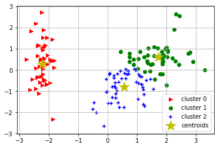

```python
# プロットを実行
kmeans_plot(3, km, X_pca[:, 0:2])
```

#### おまけ: 精度の確認

さて､これで**クラスタリング**は完了しました｡**見た感じだと､3品種のクラスタは正解のものにかなり近いのではないか**という印象を受けます｡実際のケースでは､**この結果から品種分類にあたりをつけて､詳細な調査をしていく**という流れになりますが､**今回は本来手に入っていないはずの教師データが手元にある**ので､**クラスタリングでの正答率を求めてみます**｡

```python
# y_kmを確認
y_km
```

```
array([0, 0, 0, 0, 0, 0, 0, 0, 0, 0, 0, 0, 0, 0, 0, 0, 0, 0, 0, 0, 0, 0, 0,
       0, 0, 0, 0, 0, 0, 0, 0, 0, 0, 0, 0, 0, 0, 0, 0, 0, 0, 0, 0, 0, 0, 0,
       0, 0, 0, 0, 1, 1, 1, 2, 2, 2, 1, 2, 2, 2, 2, 2, 2, 2, 2, 1, 2, 2, 2,
       2, 1, 2, 2, 2, 2, 1, 1, 1, 2, 2, 2, 2, 2, 2, 2, 1, 1, 2, 2, 2, 2, 2,
       2, 2, 2, 2, 2, 2, 2, 2, 1, 2, 1, 1, 1, 1, 2, 1, 1, 1, 1, 1, 1, 2, 2,
       1, 1, 1, 1, 2, 1, 2, 1, 2, 1, 1, 2, 1, 1, 1, 1, 1, 1, 2, 2, 1, 1, 1,
       2, 1, 1, 1, 2, 1, 1, 1, 2, 1, 1, 2], dtype=int32)
```

```python
# 正解ラベルを作る
# プロットを見ると､このときはversicolorとversinicaのlabelが逆になっている
# 両者のラベルを入れ替えて､正解ラベルをつくる
y_correct = np.hstack((y[0:50], y[100:150]))
y_correct = np.hstack((y_correct, y[50:100]))
y_correct
```

```
array([0, 0, 0, 0, 0, 0, 0, 0, 0, 0, 0, 0, 0, 0, 0, 0, 0, 0, 0, 0, 0, 0, 0,
       0, 0, 0, 0, 0, 0, 0, 0, 0, 0, 0, 0, 0, 0, 0, 0, 0, 0, 0, 0, 0, 0, 0,
       0, 0, 0, 0, 2, 2, 2, 2, 2, 2, 2, 2, 2, 2, 2, 2, 2, 2, 2, 2, 2, 2, 2,
       2, 2, 2, 2, 2, 2, 2, 2, 2, 2, 2, 2, 2, 2, 2, 2, 2, 2, 2, 2, 2, 2, 2,
       2, 2, 2, 2, 2, 2, 2, 2, 1, 1, 1, 1, 1, 1, 1, 1, 1, 1, 1, 1, 1, 1, 1,
       1, 1, 1, 1, 1, 1, 1, 1, 1, 1, 1, 1, 1, 1, 1, 1, 1, 1, 1, 1, 1, 1, 1,
       1, 1, 1, 1, 1, 1, 1, 1, 1, 1, 1, 1])
```

```python
# 正答数を累積
correct_ans = 0
for i in range(len(y_correct)):
    if y_km[i] == y_correct[i]:
        correct_ans += 1

# 正答率を出力
correct_ans / len(y)
```

```
0.8333333333333334
```

## 13.5 k-means法の弱点と対策

さて､**irisデータ**を用いた**クラスタリング**は､**かなりの精度が出ました**｡その理由には**irisデータが単純である**ということもありますが､**k-means法がクラスタリングを適切に行える強力なアルゴリズムである**ということもあります｡さて､そんな**k-means法**ですが､**実はいくつかの弱点があります**｡**k-means法**を利用するときには､**その弱点を理解し､対策できるところは対策をしていかなくてはなりません**｡それについて以下で解説します｡

### 13.5.1 弱点1. 超球状でないクラスタや､サンプル数の異なるクラスタの検出が苦手

#### 対策: なし

最初の弱点は､**適切に分割できるデータ点の分布に条件がある**ということです｡実は､**k-meansの目的関数である $SSE$ は式の都合上､超球状でサンプル数が同程度のクラスタが生まれることを暗黙の内に仮定しています**｡**超球状になりやすい理由**は､**ユークリッド距離の二乗を累積するので､距離が大きいことに厳しい罰則がかかる**ことなどであり､**クラスタごとのサンプル数がおおよそ等しくなりやすい理由**は､**クラスタごとの誤差平方和（SE）が等しく重み付けされていること**などです｡

残念ながら､**これに対策らしい対策はありません**｡**あるとしたら､目的関数を変えることくらいですが､基本的にはそれはしません**｡今のところ出来るのは､**k-meansに限界があることを知っておくくらいのことだけです**｡

#### 例1）超球状でないクラスタを検出できない例

では､説明した内容が本当かどうか､**適当なサンプルデータを作成して確認**してみましょう｡まずは､**クラスタが超球状でない場合**です｡**細長い形状**をしたクラスタを適切に検出できるかどうかを確認します｡

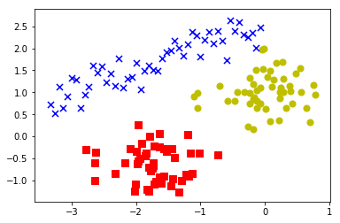

```python
# 超球上でないクラスタを作成

# サンプル数50の超球状のクラスタを生成
from sklearn.datasets import make_blobs
X_1, _ = make_blobs(n_samples=50,
                 n_features=2,
                 centers=1,
                 cluster_std=0.4,
                 center_box=[0, -2],
                 random_state=6
                )

# サンプル数50の超球状のクラスタを生成
X_2, _ = make_blobs(n_samples=50,
                 n_features=2,
                 centers=1,
                 cluster_std=0.4,
                 center_box=[0, 2],
                 random_state=9
                )

# サンプル数50の細長いクラスタを生成
from numpy.random import *
seed(2)
X_31 = np.array([i/15 for i in range(-50, 0)])
X_32 = np.array([0.5*float(i) + 2 + float(randint(100))/100 for i in X_31])
X_3 = np.hstack((X_31.reshape(-1, 1), X_32.reshape(-1, 1)))

# 2種類のクラスタを色分けして表示
plt.scatter(X_1[:, 0], X_1[:, 1], c='r', marker='s', s=50)
plt.scatter(X_2[:, 0], X_2[:, 1], c='y', marker='o', s=50)
plt.scatter(X_3[:, 0], X_3[:, 1], c='b', marker='x', s=50)
plt.show()
```

このデータを**k-means法**にかけてみましょう｡**縦長のクラスタ**を検出できるのでしょうか？

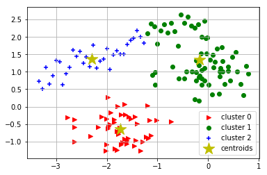

```python
# 生成したクラスタのデータを統合
X = np.vstack((X_1, X_2))
X = np.vstack((X, X_3))

# k-means法を実行
from sklearn.cluster import KMeans
km = KMeans(n_clusters=3,   # クラスタの個数を指定
            init='random',  # セントロイドの初期値の決め方を決定
            n_init=10,      # 異なるセントロイドの初期値を用いた実行回数
            max_iter=300,   # ひとつのセントロイドを用いたときの最大イテレーション回数
            tol=1e-04,      # 収束と判定するための相対的な許容誤差
            random_state=0, # セントロイドの初期化に用いる乱数生成器の状態
           )

# クラスラベルを予測
y_km = km.fit_predict(X)

# プロットを実行
# 大きなクラスタのところに､小さなクラスタが食い込んでしまっているのがわかる
kmeans_plot(3, km, X)
```

**縦長のクラスタが超球状に近づくように､緑のクラスタが食い込んでしまっている**のがわかるかと思います｡

#### 例2）クラスタ内のサンプル数が大きく異なる場合

では､次に**クラスタ内のサンプル数が大きく異なる場合**について確認してみましょう｡

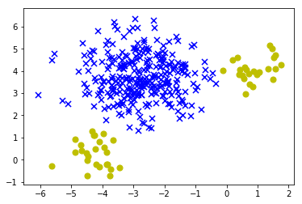

```python
# サンプル数が大きく異なるクラスタを生成
from sklearn.datasets import make_blobs

# サンプル数25のクラスタを2つ生成
X_1, _ = make_blobs(n_samples=50,
                 n_features=2,
                 centers=2,
                 cluster_std=0.5,
                 random_state=3
                )

# サンプル数300のクラスタを1つ生成
X_2, _ = make_blobs(n_samples=300,
                 n_features=2,
                 centers=1,
                 cluster_std=1.0,
                 center_box=(-5, 5),
                 random_state=5
                )

# 2種類のクラスタを色分けして表示
plt.scatter(X_1[:, 0], X_1[:, 1], c='y', marker='o', s=50)
plt.scatter(X_2[:, 0], X_2[:, 1], c='b', marker='x', s=50)
plt.show()
```

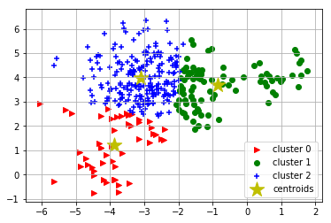

```python
# 生成したクラスタのデータを統合
X_blobs = np.vstack((X_1, X_2))

# k-means法を実行
from sklearn.cluster import KMeans
km = KMeans(n_clusters=3,   # クラスタの個数を指定
            init='random',  # セントロイドの初期値の決め方を決定
            n_init=10,      # 異なるセントロイドの初期値を用いた実行回数
            max_iter=300,   # ひとつのセントロイドを用いたときの最大イテレーション回数
            tol=1e-04,      # 収束と判定するための相対的な許容誤差
            random_state=0, # セントロイドの初期化に用いる乱数生成器の状態
           )

# クラスラベルを予測
y_km = km.fit_predict(X_blobs)

# プロットを実行
kmeans_plot(3, km, X_blobs)
```

プロットの結果を見ると､予想通り**大きなクラスタに小さなクラスタが食い込んで､クラスタ内のサンプル数を等しくさせるような力が加わっているのがわかります**｡このように､**k-means法はサンプル数が大きく違うようなクラスタも正しく検出できません**｡

### 13.5.2 弱点2. クラスタの数 $k$ を自分で決めなければならない

**k-means法**では､**クラスタの数 $k$ をあらかじめ自分で決めておかなければなりません**｡しかし､一般的に､ **$k$ は正確に決められるものではなく､ここまでの内容では分析者の勘に頼っている状態です**｡今回の**iris**のデータのように**分布を可視化することができれば､散布図からおよその見当がつきます**｡しかし､**高次元で行うときはそうは行きません**｡というより､**可視化できたとしても､下の散布図を眺めるとどれもそれっぽそうな気がします**｡何か**ある程度客観的に評価する方法**はないものでしょうか？

[figure not shown]

#### 対策①: エルボー法

そこで役に立つのが､**エルボー法**です｡エルボー法とは､**k-means法を $k$ を変えて繰り返し行い､ $SSE$ が｢がくっ｣と低下するような $k$ を見つけて目安とする方法**です｡**グラフが決まって人の肘のような形になる**ことから､**エルボー法**と名付けられています｡

[figure not shown]

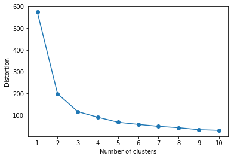

```python
# エルボー法による､適切なkの値の確認

# 各kで算出されたSSEを格納するリストを定義
distortions = []

# kを変えながらk-means法を実行
for k  in range(1,11):              # 1~10クラスタまで繰り返し計算
    km = KMeans(n_clusters=k,       # クラスタの数をk個に指定
                init='random',   # セントロイドの初期値をk-means++法で設定
                n_init=10,          # セントロイドの初期値を変えての繰り返し回数を指定
                max_iter=300,       # 一回の最適化の繰り返し回数を指定
                random_state=0)     # 乱数の生成状態を指定

    km.fit(X_pca[:, 0:2])                       # クラスタリングの計算を実行
    distortions.append(km.inertia_) # SSEをリストに格納していく

# 結果を散布図に出力
plt.plot(range(1,11), distortions,marker='o') # 1から10までのSSEを順にプロット
plt.xticks([i for i in range(1, 11)])         # 横軸のメモリを1から10までの1刻みに設定
plt.xlabel('Number of clusters')
plt.ylabel('Distortion')
plt.show()
```

**エルボー法**は､**｢ $k$ が小さすぎると､複数のクラスタを無理に統合することになるので､ $SSE$ が急に上がるだろう｣**という仮定に基づいています｡この**｢がくっと｣**というところが重要です｡なぜなら､ **$k$ が増えれば増えるほどセントロイドが多く存在することになり､近くのセントロイドを見つけるのが容易になって $SSE$ が小さくなりやすくなるという､一般的な傾向があるからです**｡**今回のケースで言えば､それらしい $k$ の値は2または3といったところでしょうか**｡

#### 対策②: シルエット分析

もうひとつの対策が**シルエット分析**です｡ここでは**シルエット係数（silhouette coefficient）**なるものを計算して､**クラスタリングの質**を判定します｡**クラスタリングの質**は何で決まるかというと､**｢似たものを似たもの扱いできていること（内部結合）｣**と､**｢似てないものを似てないもの扱いできていること（外部分離）｣**の2つです｡**シルエット係数**は**これらがどれだけ際立っているかを表す指標**になっていて､ます｡

まずは､各サンプル $\boldsymbol{x_i}$ に関して以下の2つの指標を計算します｡

**1. 凝集度**  
データ点 **$\boldsymbol{x_i}$ があるクラスタの､その他のサンプルとの平均距離**｡**小さいほど､似た者同士が密にまとまっていて､内部結合が強い**｡

**2. 乖離度**  
データ点 **$\boldsymbol{x_i}$ があるクラスタに､一番近い他のクラスタに含まれるサンプルとの平均距離**｡**大きいほど､似てないものが遠くにあって､外部分離が強い**｡

[figure not shown]

**シルエット係数**は､これらを用いて以下のように求められます｡**理論的には､シルエット係数は $-1$ ~ $+1$ の値を取ります**｡

$$シルエット係数 = \frac{乖離度 - 凝集度}{両者のうち大きい方}$$

**クラスタ内のサンプルのシルエット係数が大きいほど､､乖離度が凝集度に対して大きいことを示します**｡つまりは､**他のものと明確に区別できるクラスタが作られている**ということです｡逆に､**シルエット係数がマイナスになるようなときは､クラスタリングが上手く言っていない**と気づけます｡なぜなら､自分のクラスタ内のサンプルよりも､隣のクラスタ内のサンプルの方が近いということなので､**周囲がごちゃごちゃしている状況の中で無理なクラスタリングが行われてしまっている**ことを示しているからです｡

```python
# k-means法を実行
# 3クラスタに分ける
from sklearn.cluster import KMeans
km = KMeans(n_clusters=3,   # クラスタの個数を指定
            init='random',  # セントロイドの初期値の決め方を決定
            n_init=10,      # 異なるセントロイドの初期値を用いた実行回数
            max_iter=300,   # ひとつのセントロイドを用いたときの最大イテレーション回数
            tol=1e-04,      # 収束と判定するための相対的な許容誤差
            random_state=0, # セントロイドの初期化に用いる乱数生成器の状態
           )

# クラスラベルを予測
y_km = km.fit_predict(X_pca[:, 0:2])
```

```python
from sklearn.metrics import silhouette_samples

# 全サンプルのシルエット係数を計算
# (X, y_km, 利用する距離の種類)
# 'euclidiean' はユークリッド距離
s = silhouette_samples(X_pca[:, 0:2], y_km, metric='euclidean')
```

```python
# シルエット係数を確認
s
```

```
array([ 0.7437586 ,  0.58954614,  0.69409517,  0.64122155,  0.73369006,
        0.61141915,  0.73511038,  0.74362968,  0.50135509,  0.65881326,
        0.68571458,  0.74237058,  0.59842831,  0.56327201,  0.56628677,
        0.4531917 ,  0.62528033,  0.73935287,  0.59722791,  0.68463541,
        0.69664134,  0.70278381,  0.71659332,  0.65310985,  0.73907159,
        0.56794047,  0.72282242,  0.735419  ,  0.73779078,  0.68998794,
        0.64387074,  0.67403197,  0.59277666,  0.53806428,  0.65881326,
        0.70266667,  0.70991422,  0.65881326,  0.57082221,  0.74027388,
        0.74561258,  0.07387569,  0.66820107,  0.70668142,  0.66918434,
        0.57672248,  0.68618886,  0.68751404,  0.69636903,  0.72662061,
        0.46212585,  0.21972257,  0.48205205,  0.56842335,  0.18797752,
        0.58705332,  0.29071226,  0.4273799 ,  0.07138504,  0.61145173,
        0.43386335,  0.37349002,  0.55612643,  0.37048656,  0.5300063 ,
        0.26246967,  0.45841515,  0.61241816,  0.45906888,  0.61730613,
        0.10900922,  0.5350552 ,  0.43356197,  0.50707618,  0.29358085,
        0.08030026,  0.06093282,  0.43397581,  0.41314614,  0.60564043,
        0.59403512,  0.58734249,  0.61578107,  0.43777815,  0.50268433,
        0.15927388,  0.3650558 ,  0.51458696,  0.47264321,  0.61799592,
        0.62795121,  0.25622038,  0.62806671,  0.45361512,  0.62319861,
        0.45872978,  0.53641247,  0.39923994,  0.46010598,  0.58986426,
        0.62682497,  0.41507594,  0.5944806 ,  0.22433656,  0.54387247,
        0.53549456,  0.59477736,  0.5602107 ,  0.02301233,  0.50049898,
        0.53833295,  0.00083154,  0.58314569,  0.44751641,  0.07847957,
        0.59222715,  0.44309166,  0.43052702,  0.36508046,  0.44460901,
        0.62414954,  0.44971076,  0.47862723,  0.20957798,  0.60644629,
        0.62018394,  0.20310478,  0.01109978,  0.27996232,  0.61105691,
        0.50927936,  0.4239499 ,  0.30777848,  0.22873697,  0.42397951,
        0.52998389,  0.58466791,  0.46817319,  0.08518424,  0.62425795,
        0.61723868,  0.62664371,  0.41507594,  0.62546358,  0.61467697,
        0.57395067,  0.26209185,  0.46664301,  0.54811396,  0.09858802])
```

```python
# サンプル数と同じ150個のシルエット係数が算出されていることを確認
len(s)
```

```
150
```

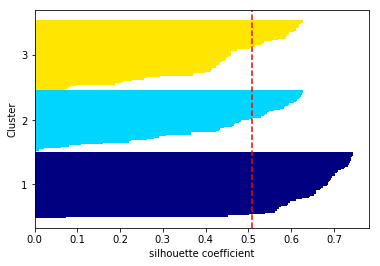

```python
# シルエット図を出力
from matplotlib import cm

# シルエット図を出力する関数を定義
def draw_silhouettes(X, y_km):
    cluster_labels = np.unique(y_km)                     # クラスラベルを重複なく抽出
    n_clusters = cluster_labels.shape[0]                 # クラスタの数を算出

    # シルエット係数を計算
    # (X, y_km, 距離の種類)
    s = silhouette_samples(X, y_km, metric='euclidean')

    # 各ラベルごとにシルエット図を描画
    y_ax_lower, y_ax_upper= 0, 0                         # シルエット図の上端と下端の初期値を設定
    yticks = []                                          # 縦軸のメモリ位置を格納するリストを生成
    for i, label in enumerate(cluster_labels):
            label_s = s[y_km==label]                     # 該当するクラスタについて､シルエット係数を算出
            label_s.sort()                               # シルエット係数を小さい順に並べ替える
            y_ax_upper += len(label_s)                   # シルエット図の上端を､サンプルの数だけ引き上げる
            color = cm.jet(float(i) / n_clusters)        # color mapから色を取得
            plt.barh(range(y_ax_lower, y_ax_upper),      # 横軸の範囲を指定
                             label_s,                    # バーの幅を指定
                             height=1.0,                 # バーの厚みを指
                             color=color)                # バーの色を指定
            yticks.append((y_ax_lower + y_ax_upper) / 2) # クラスタラベルの表示位置を追加
            y_ax_lower += len(label_s)                   # シルエット図の下端を､サンプルの数だけ引き上げる


    plt.axvline(np.mean(s), color="red", linestyle="--") # 係数の平均値に破線を引く(横軸の値, 色, 線の形式)
    plt.yticks(yticks, cluster_labels + 1)               # クラスタレベルを表示(位置, 縦軸の値)
    plt.ylabel('Cluster')
    plt.xlabel('silhouette coefficient')
    plt.show()

# シルエット図を出力
draw_silhouettes(X_pca[:, 0:2], y_km)
```

#### シルエット図の見方

**シルエット図**は､以下の**2点**に注目して**クラスタリングの質**を評価していきます｡そして､**適切な $k$ の値を見つける**ことを目指します｡

[figure not shown]

#### チェック項目1. クラスタ内のサンプル数は均等になっているか？

**シルエット図の縦の厚み**は､**クラスタ内のサンプル数**を表していて､ここを見ることによって､**適切なクラスタ数にあたりを付けることができます**｡**k-means法**は性質上､**正常に収束すると大体同じ数のサンプルが集まったクラスタを検出する**ので､ここにばらつきがあると､**分割しきれていない大きなサンプル群**があったり､**無駄に細かく分けてしまったクラスタがある**ことがわかります｡つまりは､ **$k$ の値が適切ではないのです**｡

[figure not shown]

#### チェック項目2. シルエット係数が小さすぎるサンプルはないか？

**シルエット係数**は､**クラスタの内部結合と外部分離の度合いを表す指標**だと言いました｡このことから､**シルエット係数が小さいサンプルは､細かくクラスタ分けされていなかったり（内部結合が弱い）､他のクラスタの近くにあって所属が曖昧であったり（外部分離が弱い）**します｡**これがマイナスになったりしてしまうと､クラスタリングは上手く言っていないと明確に判断できます｡**｡

#### クラスタリングが適切でない場合のシルエット図

では､ $k$ の値を変えて､クラスタリングが適切でない場合のシルエット図を見ていきましょう｡まずは､ **$k$ が小さすぎる場合**</font>です｡**シルエット係数の値自体は問題なさそう**ですが､**サンプル数が大きく偏っている**ことがわかります｡こういった場合は､**k-meansが適切にクラスタリングできる状況に反している**ので､ $k$ は不適切だと思われます｡

```python
# k-means法を実行
# 2クラスタに分ける
from sklearn.cluster import KMeans
km = KMeans(n_clusters=2,   # クラスタの個数を指定
            init='random',  # セントロイドの初期値の決め方を決定
            n_init=10,      # 異なるセントロイドの初期値を用いた実行回数
            max_iter=300,   # ひとつのセントロイドを用いたときの最大イテレーション回数
            tol=1e-04,      # 収束と判定するための相対的な許容誤差
            random_state=0, # セントロイドの初期化に用いる乱数生成器の状態
           )
y_km = km.fit_predict(X_pca[:, 0:2])
```

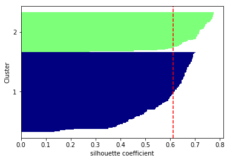

```python
# シルエット図を描画
draw_silhouettes(X_pca[:, 0:2], y_km)
```

```python
# k-means法を実行
# 4クラスタに分ける
from sklearn.cluster import KMeans
km = KMeans(n_clusters=4,   # クラスタの個数を指定
            init='random',  # セントロイドの初期値の決め方を決定
            n_init=10,      # 異なるセントロイドの初期値を用いた実行回数
            max_iter=300,   # ひとつのセントロイドを用いたときの最大イテレーション回数
            tol=1e-04,      # 収束と判定するための相対的な許容誤差
            random_state=0, # セントロイドの初期化に用いる乱数生成器の状態
           )
y_km = km.fit_predict(X_pca[:, 0:2])
```

では､逆に** $k$ が大きすぎる場合を見てみましょう**｡この場合は､サンプル数が等しくならないことに加えて､**シルエット係数がマイナスのものが出てきてしまっています**｡**やはり､ $k$ の値が適切でないことがわかります**｡

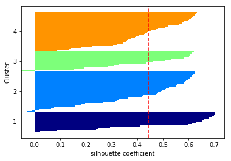

```python
# シルエット図を描画
draw_silhouettes(X_pca[:, 0:2], y_km)
```

### 13.5.3 弱点3. セントロイドの初期値次第で､最終的なクラスタが大きく変わる

**k-means法**は**セントロイドの初期値を､ランダムに決定します**｡そのときに､**初期値次第では､どう見ても無理のあるクラスタに収束してしまうことがあります**｡このような､**初期値によって結果が変わってしまう性質を｢初期値依存性｣といいます**｡

[figure not shown]

**こうした収束を抑制するための対策**には､以下の2つがあります｡

**対策①: k-means法を繰り返し実行する**  
最も単純な方法は､**k-means法を何回か繰り返し実行して､$SSE$ が一番小さくなった学習器を採用することです**｡そうすることで､**無理のある学習器を採用してしまう確率を減らすことができます**｡ **`KMeans()` の引数である `n_init` の値を変えることで実行できます**｡

**対策②: k-means++法を利用する**  
次に考えられるのは､**セントロイドの初期値のとり方を工夫する**という方法です｡**k-means++法**はそうした工夫のひとつで､**｢無理のある収束は､セントロイドの初期値が近いときに起こりやすい｣**という傾向に注目して**､離れたサンプル同士で初期値をとるようにしています**｡実行するためには､KMeansの引数の `init='random'` のところを `init='k-means++'` とするだけで実行できます｡

というよりも実は､** ```init``` のデフォルト値は ```k-means++``` になっているので､特に指定しなければk-means++法で初期値が設定されます**｡

[figure not shown]

監修: 東京女子大学情報処理センター 浅川伸一